# Differential Expression

Christoph Hafemeister

2020-12-15

With this vignette we show how data that has been transformed using the `vst` function can be tested for differentially expressed genes across subsets of cells.

### Load some data

First we will follow the [Seurat clustering tutorial](https://satijalab.org/seurat/pbmc3k_tutorial.html) and load a dataset of Peripheral Blood Mononuclear Cells (PBMC) freely available from 10X Genomics. There are 2,700 single cells that were sequenced on the Illumina NextSeq 500. The raw data can be found [here](https://s3-us-west-2.amazonaws.com/10x.files/samples/cell/pbmc3k/pbmc3k_filtered_gene_bc_matrices.tar.gz). We will use the cell type identies from the Seurat tutorial in this vignette.

```r
pbmc_clusters <- readRDS(file = "~/Projects/data/pbmc3k_celltypes.rds")
pbmc_data <- readRDS(file = "~/Projects/data/pbmc3k_umi_counts.Rds")
pbmc_data <- pbmc_data[, names(pbmc_clusters)]

class(pbmc_data)
```

```
#> [1] "dgCMatrix"
#> attr(,"package")
#> [1] "Matrix"
```

```r
dim(pbmc_data)
```

```
#> [1] 32738  2638
```

`pbmc_data` is a sparse matrix of UMI counts (32,738 genes as rows and 2,638 cells as columns). Perform the variance stabilizing transformation:

```r
set.seed(43)
vst_out <- sctransform::vst(pbmc_data, latent_var = c("log_umi_per_gene"), return_gene_attr = TRUE,
    return_cell_attr = TRUE, verbosity = 1)
```

```
#> Calculating cell attributes from input UMI matrix: log_umi_per_gene
#> Variance stabilizing transformation of count matrix of size 12519 by 2638
#> Model formula is y ~ log_umi_per_gene
#> Get Negative Binomial regression parameters per gene
#> Using 2000 genes, 2638 cells
#> Found 154 outliers - those will be ignored in fitting/regularization step
#> Second step: Get residuals using fitted parameters for 12519 genes
#> Wall clock passed: Time difference of 16.83868 secs
```

Perform differential expression test between the two monocyte clusters.

```r
res1 <- sctransform:::compare_expression(x = vst_out, umi = pbmc_data, group = pbmc_clusters,
    val1 = "CD14+ Monocytes", val2 = "FCGR3A+ Monocytes", verbosity = 1)
```

```
#> weights
#> 0.663883089770355  2.02547770700637
#>               479               157
#> Testing for differential gene expression between two groups
#> Cells in group 1: 479
#> Cells in group 2: 157
#> Testing 8577 genes
```

By default, for every gene `compare_expression` uses a likelihood ratio test between two models. The first model has only an intercept term, while the second model also includes a group indicator variable, effectively fitting one intercept per group. Both models include an offset term to account for the expected UMI counts given the `vst` model. Model 1: $\log(\mu) = \beta_0 + \log(o)$, model 2: $\log(\mu) = \beta_1 + \beta_2 x + \log(o)$, where $\mu$ is the expected number of UMI counts of the given gene, $o$ the offset term (expected value under the regularized negative binomial regression model - see variance stabilizing transformation vignette), $x$ indicator variable that is 1 for cells belonging to group 2 and 0 otherwise. A negative binomial error distribution is assumed and both models use the regularized theta from the `vst` model to specify variance. The fold-change can be determined directly from the model 2 coefficient: $\log_2(e^{\beta_2})$

The results are ordered by p-value and we show the top ranking genes for each group.

```r
head(subset(res1, log_fc < 0), 10)
```

|  | p_value | log_fc | fdr | mean1 | mean2 | mean | mean_weighted |
| --- | --- | --- | --- | --- | --- | --- | --- |
| S100A9 | 0 | -2.954240 | 0 | 31.1127349 | 4.7643312 | 24.6084906 | 17.9385330 |
| S100A8 | 0 | -3.733798 | 0 | 16.4718163 | 1.4840764 | 12.7720126 | 8.9779464 |
| LYZ | 0 | -2.229480 | 0 | 45.9081420 | 11.8343949 | 37.4968553 | 28.8712684 |
| CD14 | 0 | -3.100173 | 0 | 1.6555324 | 0.2229299 | 1.3018868 | 0.9392311 |
| LGALS2 | 0 | -3.144745 | 0 | 4.2004175 | 0.5732484 | 3.3050314 | 2.3868330 |
| CLEC4E | 0 | -27.626690 | 0 | 0.1711900 | 0.0000000 | 0.1289308 | 0.0855950 |
| RNASE2 | 0 | -27.155915 | 0 | 0.1273486 | 0.0000000 | 0.0959119 | 0.0636743 |
| CD99 | 0 | -2.218908 | 0 | 0.9269311 | 0.2356688 | 0.7562893 | 0.5812999 |
| LTB4R | 0 | -27.257830 | 0 | 0.1315240 | 0.0000000 | 0.0990566 | 0.0657620 |
| RNASE6 | 0 | -4.513046 | 0 | 0.3820459 | 0.0191083 | 0.2924528 | 0.2005771 |

```r
head(subset(res1, log_fc > 0), 10)
```

|  | p_value | log_fc | fdr | mean1 | mean2 | mean | mean_weighted |
| --- | --- | --- | --- | --- | --- | --- | --- |
| FCGR3A | 0 | 5.0759758 | 0 | 0.2087683 | 8.191083 | 2.179245 | 4.199925 |
| RPS19 | 0 | 1.3777870 | 0 | 10.2212944 | 33.312102 | 15.921384 | 21.766698 |
| LST1 | 0 | 1.6371063 | 0 | 4.9227557 | 18.082802 | 8.171384 | 11.502779 |
| IFITM2 | 0 | 2.5217858 | 0 | 1.8392484 | 12.261147 | 4.411950 | 7.050198 |
| FCER1G | 0 | 1.4939451 | 0 | 4.5093946 | 15.101911 | 7.124214 | 9.805653 |
| TMSB4X | 0 | 0.7065006 | 0 | 54.8810021 | 107.261146 | 67.811321 | 81.071074 |
| RHOC | 0 | 3.4566935 | 0 | 0.2359081 | 2.980892 | 0.913522 | 1.608400 |
| B2M | 0 | 0.9382867 | 0 | 30.7515658 | 68.700637 | 40.119497 | 49.726101 |
| AIF1 | 0 | 1.1503351 | 0 | 5.8956159 | 15.535032 | 8.275157 | 10.715324 |
| MALAT1 | 0 | 1.0434667 | 0 | 23.7390397 | 55.528662 | 31.586478 | 39.633851 |

Generate a volcano-plot

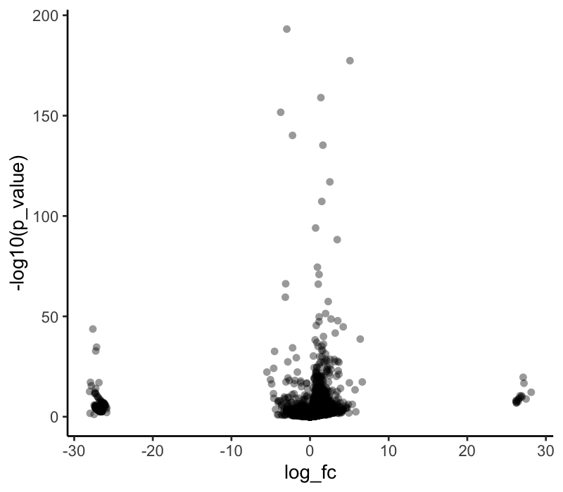

```r
ggplot(res1, aes(log_fc, -log10(p_value))) + geom_point(alpha = 0.4, shape = 16)
```

Genes only detected in one group receive large absolute values for fold change, but not necessarily the smallest p-values.

We can also test one cluster vs all others. For example CD8 T cells:

```r
res2 <- sctransform:::compare_expression(x = vst_out, umi = pbmc_data, group = pbmc_clusters,
    val1 = setdiff(pbmc_clusters, "CD8 T cells"), val2 = "CD8 T cells", verbosity = 1)
```

```
#> weights
#> 0.566094420600858  4.28246753246753
#>              2330               308
#> Testing for differential gene expression between two groups
#> Cells in group 1: 2330
#> Cells in group 2: 308
#> Testing 12295 genes
```

```r
head(subset(res2, log_fc > 0), 10)
```

|  | p_value | log_fc | fdr | mean1 | mean2 | mean | mean_weighted |
| --- | --- | --- | --- | --- | --- | --- | --- |
| GZMK | 0 | 4.8716265 | 0 | 0.0905579 | 2.2759740 | 0.3457165 | 1.1832660 |
| CD8A | 0 | 3.5588153 | 0 | 0.0888412 | 0.8798701 | 0.1811979 | 0.4843557 |
| CCL5 | 0 | 3.6261296 | 0 | 0.9266094 | 10.2889610 | 2.0197119 | 5.6077852 |
| B2M | 0 | 0.7363286 | 0 | 43.3502146 | 59.9577922 | 45.2892343 | 51.6540034 |
| HLA-C | 0 | 1.0373969 | 0 | 7.8866953 | 12.4448052 | 8.4188779 | 10.1657502 |
| CD3D | 0 | 1.4483011 | 0 | 1.3098712 | 2.8344156 | 1.4878696 | 2.0721434 |
| IL32 | 0 | 1.6658035 | 0 | 1.7703863 | 4.6655844 | 2.1084155 | 3.2179853 |
| MALAT1 | 0 | 0.5285737 | 0 | 58.5094421 | 71.5909091 | 60.0367703 | 65.0501756 |
| HLA-A | 0 | 0.9716494 | 0 | 6.4484979 | 9.9610390 | 6.8586050 | 8.2047684 |
| GZMH | 0 | 3.8910112 | 0 | 0.1510730 | 1.9123377 | 0.3567096 | 1.0317053 |

And plot the distribution in raw UMI space and Pearson residual space.

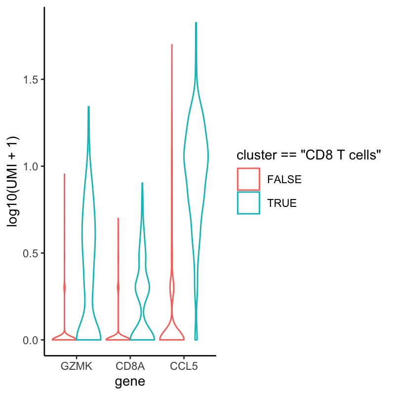

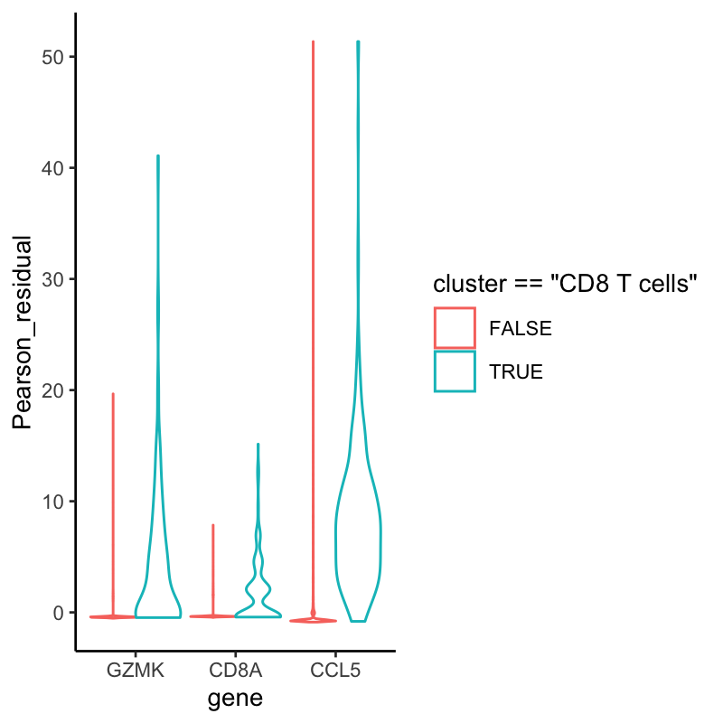

```r
goi <- rownames(subset(res2, log_fc > 0))[1:3]
df <- melt(t(as.matrix(pbmc_data[goi, ])), varnames = c("cell", "gene"), value.name = "UMI")
df$cluster <- pbmc_clusters
ggplot(df, aes(x = gene, y = log10(UMI + 1), color = cluster == "CD8 T cells")) +
    geom_violin(scale = "width")
df <- melt(t(as.matrix(vst_out$y[goi, ])), varnames = c("cell", "gene"), value.name = "Pearson_residual")
df$cluster <- pbmc_clusters
ggplot(df, aes(x = gene, y = Pearson_residual, color = cluster == "CD8 T cells")) +
    geom_violin(scale = "width")
```